# Differential Gene Expression Analysis

Our Patient Data | Targeted

Mark Edward M. Gonzales[^1]

Dr. Anish M.S. Shrestha[^2]

## I. Preliminaries

### Loading libraries

```r
library("tidyverse")
library("tibble")
library("msigdbr")
library("ggplot2")
library("TCGAbiolinks")
library("RNAseqQC")
library("DESeq2")
library("ensembldb")
library("purrr")
library("magrittr")
library("vsn")
library("matrixStats")
library("dplyr")
library("grex")
library("tximport")
```

## II. Converting transcript-level to gene-level abundance

Read the quantification files generated by Salmon.

```r
SALMON_DIR <- "../data/patient/human_transcriptome/quantification/salmon/"
samples <- list.files(path=SALMON_DIR, full.names=TRUE)
files <- file.path(samples, "quant.sf")
names(files) <- str_replace(samples, SALMON_DIR, "")
files
```

```
                                                                     2235-N                                                                      2235-T
"../data/patient/human_transcriptome/quantification/salmon/2235-N/quant.sf" "../data/patient/human_transcriptome/quantification/salmon/2235-T/quant.sf"
                                                                     2239-N                                                                      2239-T
"../data/patient/human_transcriptome/quantification/salmon/2239-N/quant.sf" "../data/patient/human_transcriptome/quantification/salmon/2239-T/quant.sf"
                                                                     2249-N                                                                      2249-T
"../data/patient/human_transcriptome/quantification/salmon/2249-N/quant.sf" "../data/patient/human_transcriptome/quantification/salmon/2249-T/quant.sf"
                                                                     2252-N                                                                      2252-T
"../data/patient/human_transcriptome/quantification/salmon/2252-N/quant.sf" "../data/patient/human_transcriptome/quantification/salmon/2252-T/quant.sf"
```

Load the transcript-to-gene mapping table.

```r
tx2gene <- read.delim("../data/patient/tx2gene.gencode.v47.tsv", header=FALSE)
names(tx2gene) <- c("Transcript", "Gene", "Symbol")
tx2gene
```

| Transcript | Gene | Symbol |
| --- | --- | --- |
| ENST00000832824.1 | ENSG00000290825.2 | DDX11L16 |
| ENST00000832825.1 | ENSG00000290825.2 | DDX11L16 |
| ENST00000832826.1 | ENSG00000290825.2 | DDX11L16 |
| ENST00000832827.1 | ENSG00000290825.2 | DDX11L16 |
| ENST00000832828.1 | ENSG00000290825.2 | DDX11L16 |
| ENST00000832829.1 | ENSG00000290825.2 | DDX11L16 |
| ENST00000832830.1 | ENSG00000290825.2 | DDX11L16 |
| ENST00000832837.1 | ENSG00000290825.2 | DDX11L16 |
| ENST00000832836.1 | ENSG00000290825.2 | DDX11L16 |
| ENST00000832832.1 | ENSG00000290825.2 | DDX11L16 |

[output cut: 990 more lines]

Convert the transcript-level to gene-level abundance.

```r
txi <- tximport(files, type = "salmon", tx2gene = tx2gene)
counts_matrix <- round(txi$counts)
rownames(counts_matrix) <- cleanid(rownames(counts_matrix))
head(counts_matrix)
```

```
                2235-N 2235-T 2239-N 2239-T 2249-N 2249-T 2252-N 2252-T
ENSG00000000003   1266   1192   1546   1754   1252   1744    206   1933
ENSG00000000005      5     20      5      6     11      4      2     27
ENSG00000000419    464   1391    453   1420    457   1493    228   1489
ENSG00000000457    419    349    299    268    263    271    161    243
ENSG00000000460     54    191     64    152     68    238     57    172
ENSG00000000938     55    169     77     98    103    157    125    322
```

Construct the metadata table.

```r
condition <- c()
for (col in colnames(counts_matrix)) {
  if (endsWith(col, "-N")) {
    condition <- c(condition, "normal")
  } else if (endsWith(col, "-T")) {
    condition <- c(condition, "tumor")
  } else {
    condition <- c(condition, "error")
  }
}

meta <- data.frame(condition = factor(condition))
rownames(meta) <- colnames(counts_matrix)

# Each sample should either be "normal" or "tumor"
stopifnot(any(meta == "error") == FALSE)
meta
```

|  | condition |
| --- | --- |
| 2235-N | normal |
| 2235-T | tumor |
| 2239-N | normal |
| 2239-T | tumor |
| 2249-N | normal |
| 2249-T | tumor |
| 2252-N | normal |
| 2252-T | tumor |

## III. Differential gene expression analysis

References:

- Official documentation: https://www.bioconductor.org/packages/release/bioc/vignettes/DESeq2/inst/doc/DESeq2.html
- Good balance of theory and hands-on: https://hbctraining.github.io/DGE_workshop/lessons/04_DGE_DESeq2_analysis.html
- Quality control: https://cran.r-project.org/web/packages/RNAseqQC/vignettes/introduction.html

Construct the `DESeqDataSet` object.

```r
dds <- DESeqDataSetFromTximport(
  txi,
    colData = meta,
    design = ~condition
)
```

```
using counts and average transcript lengths from tximport
```

#### Quality control

Display quality control (QC) plots (refer to https://cran.r-project.org/web/packages/RNAseqQC/vignettes/introduction.html)

- Total sample counts
  - Total number of counts for each sample
  - We typically expect all samples to have total counts within the same order of magnitude
- Library complexity
  - What fraction of counts is taken up by what fraction of genes
  - Samples showing a different library complexity than the rest might be considered low quality
- Gene detection
  - Number of detected genes for each sample

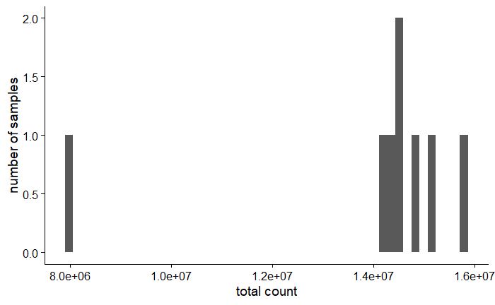

```r
plot_total_counts(dds)
```

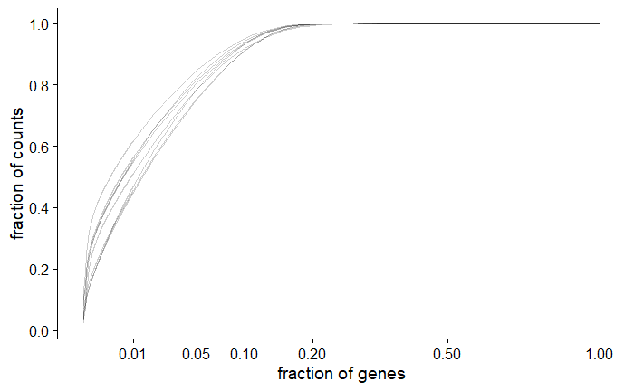

```r
plot_library_complexity(dds)
```

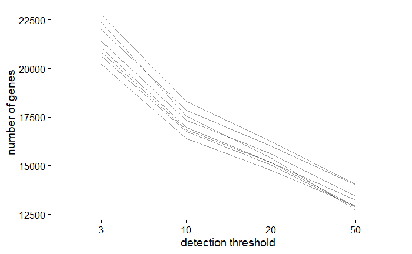

```r
plot_gene_detection(dds)
```

Perform gene filtering.

```r
dds <- filter_genes(dds)
```

Transform the read counts.

From https://chipster.csc.fi/manual/deseq2-transform.html:  
You can use the resulting transformed values only for visualization and clustering, not for differential expression analysis which needs raw counts.

```r
vsd <- vst(dds)
```

```
using 'avgTxLength' from assays(dds), correcting for library size
```

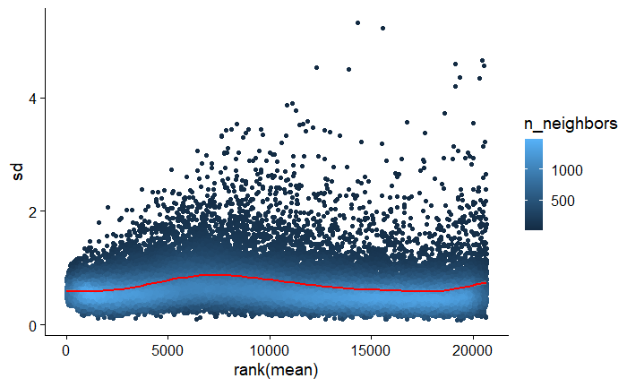

```r
mean_sd_plot(vsd)
```

Check the clustering of the samples.

If you encounter the error `Error in loadNamespace(x) : there is no package called 'ComplexHeatmap'`, uncomment and run the following code block:

```r
# install.packages("devtools", dependencies = TRUE)
# devtools::install_github("jokergoo/ComplexHeatmap")
```

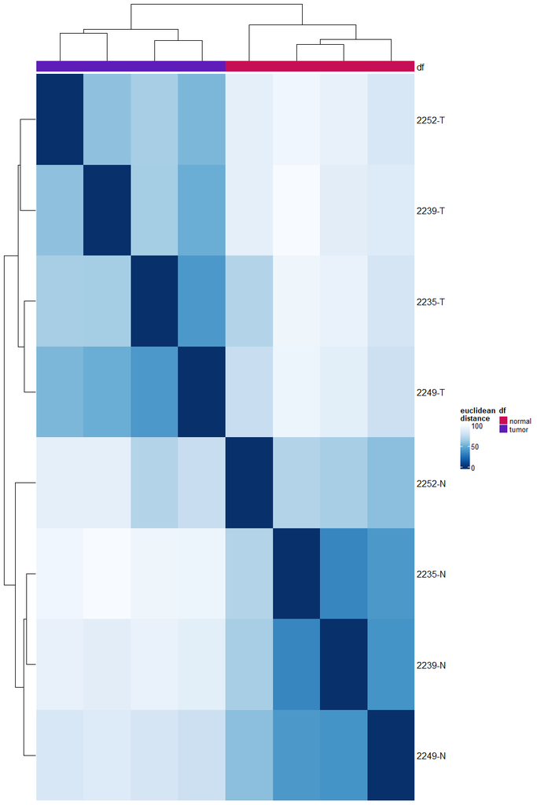

```r
set.seed(42)
plot_sample_clustering(vsd, anno_vars = c("condition"), distance = "euclidean")
```

Perform principal component analysis (PCA).

```r
pca_plot <- plotPCA(vsd, intgroup = "condition")
```

```
using ntop=500 top features by variance
```

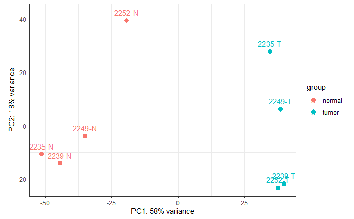

```r
pca_plot + geom_text(aes(label = vsd@colData@rownames), position = position_nudge(y = 3)) + theme_bw()
```

### Regulated Cell Death

We obtain the gene sets from RCDdb: https://pmc.ncbi.nlm.nih.gov/articles/PMC11384979/

```r
RCDdb <- "../data/public/rcd-gene-list/RCDdb/"
projects <- c("patient")
```

Write utility functions for filtering the gene sets, performing differential gene expression analysis, and plotting the results.

```r
filter_gene_set_and_perform_dgea <- function(genes) {
  rcd <- list()

  for (project in projects) {
    rownames(genes) <- genes$gene_id
    rcd[[project]] <- counts_matrix[rownames(counts_matrix) %in% genes$gene_id, ]
    rcd[[project]] <- rcd[[project]][, rownames(meta)]
  }

  dds_rcd <- list()
  res_rcd <- list()

  for (project in projects) {
    print(project)
    print("=============")
    dds <- DESeqDataSetFromMatrix(
      countData = rcd[[project]],
      colData = meta,
      design = ~condition
    )
    dds <- filter_genes(dds)
    dds$condition <- relevel(dds$condition, ref = "normal")
    dds_rcd[[project]] <- DESeq(dds)
    res_rcd[[project]] <- results(dds_rcd[[project]])
  }

  deseq.bbl.data <- list()

  for (project in projects) {
    deseq.results <- res_rcd[[project]]
    deseq.bbl.data[[project]] <- data.frame(
      row.names = rownames(deseq.results),
      baseMean = deseq.results$baseMean,
      log2FoldChange = deseq.results$log2FoldChange,
      lfcSE = deseq.results$lfcSE,
      stat = deseq.results$stat,
      pvalue = deseq.results$pvalue,
      padj = deseq.results$padj,
      cancer_type = project,
      gene_symbol = genes[rownames(deseq.results), "gene"]
    )
  }

  deseq.bbl.data.combined <- bind_rows(deseq.bbl.data)
  deseq.bbl.data.combined <- dplyr::filter(deseq.bbl.data.combined, abs(log2FoldChange) >= 1.5 & padj < 0.05)

  return(deseq.bbl.data.combined)
}
```

```r
plot_dgea <- function(deseq.bbl.data.combined) {
  sizes <- c("<10^-15" = 4, "10^-10" = 3, "10^-5" = 2, "0.05" = 1)

  deseq.bbl.data.combined <- deseq.bbl.data.combined %>%
    mutate(fdr_category = cut(padj,
      breaks = c(-Inf, 1e-15, 1e-10, 1e-5, 0.05),
      labels = c("<10^-15", "10^-10", "10^-5", "0.05"),
      right = FALSE
    ))

  top_genes <- deseq.bbl.data.combined %>%
    group_by(cancer_type) %>%
    mutate(rank = rank(-abs(log2FoldChange))) %>%
    dplyr::filter(rank <= 10) %>%
    ungroup()

  ggplot(top_genes, aes(y = cancer_type, x = gene_symbol, size = fdr_category, fill = log2FoldChange)) +
    geom_point(alpha = 0.5, shape = 21, color = "black") +
    scale_size_manual(values = sizes) +
    scale_fill_gradient2(low = "blue", mid = "white", high = "red", limits = c(min(deseq.bbl.data.combined$log2FoldChange), max(deseq.bbl.data.combined$log2FoldChange))) +
    theme_minimal() +
    theme(
      axis.text.x = element_text(size = 9, angle = 90, hjust = 1)
    ) +
    theme(legend.position = "bottom") +
    theme(legend.position = "bottom") +
    labs(size = "Adjusted p-value", fill = "log2 FC", y = "Cancer type", x = "Gene")
}
```

#### 1. Necroptosis

Fetch the gene set of interest.

```r
genes <- read.csv(paste0(RCDdb, "Necroptosis.csv"))
genes$gene_id <- cleanid(genes$gene_id)
genes <- distinct(genes, gene_id, .keep_all = TRUE)
genes <- subset(genes, gene_id != "")
genes
```

|  | deathtype | gene | description | gene_id | gene_biotype | pmid | comment |
| --- | --- | --- | --- | --- | --- | --- | --- |
| 1 | Necroptosis | GLUD1 | glutamate dehydrogenase 1 | ENSG00000148672 | protein_coding | 30029665 | The activation of GLUD1 led to the disruption of metabolic balance and cell death. Resibufogenin induces cell death dependent on necroptosis by activating RIP3 and phosphorylating mixed lineage kinase… |
| 2 | Necroptosis | ALOX15 | arachidonate 15-lipoxygenase | ENSG00000161905 | protein_coding | 29891910 | Necroptosis occurred in the skin in the absence of ALOX15. In addition, apoptosis markers were also upregulated in the dorsal skin of ALOX15 KO mice. ALOX15 plays a critical role in maintaining skin h… |
| 3 | Necroptosis | FTH1 | ferritin heavy chain 1 | ENSG00000167996 | protein_coding | 32984939 | Low concentrations of boron can promote cell proliferation and differentiation by inhibiting the expression of FTH1, reducing iron ion accumulation and ROS production in cells, and thereby reducing ce… |
| 4 | Necroptosis | CAPN1 | calpain 1 | ENSG00000014216 | protein_coding | 37168851 | CAPN1 activation has been demonstrated to degrade cytoskeleton proteins, vital enzymes, and mitochondrial membrane-related proteins, which may play a primary role in ischemia-induced neuronal injury, … |
| 5 | Necroptosis | CASP1 | caspase 1 | ENSG00000137752 | protein_coding | 36389690 | CASP1 is involved in the regulation of necroptosis. In this study, CASP1 was one of the three selected necroptosis-related genes used to construct a prognostic model and risk score system to predict t… |
| 6 | Necroptosis | BAX | BCL2 associated X, apoptosis regulator | ENSG00000087088 | protein_coding | 32768820 | Chlorpyrifos (CPF) could promote the expression of BAX mRNA and protein and induce apoptosis and necroptosis of L8824 cells. CPF could also activate the expression of genes related to the Necroptosis … |
| 7 | Necroptosis | BCL2 | BCL2 apoptosis regulator | ENSG00000171791 | protein_coding | 31634424 | Fisetin can reduce the expression of the anti-apoptotic protein BCL2 and increase the levels of pro-apoptotic proteins Bax, caspase-3, and PARP in HepG2 cells, inducing cell death through apoptosis pa… |
| 8 | Necroptosis | FADD | Fas associated via death domain | ENSG00000168040 | protein_coding | 36191211 | The absence of Caspase-8 or FADD can lead to spontaneous activation of RIPK3, phosphorylation of MLKL, and necroptosis.the proteolytic activity of the FADD/Caspase-8 complex can inhibit ZBP1-induced n… |
| 9 | Necroptosis | RIPK1 | receptor interacting serine/threonine kinase 1 | ENSG00000137275 | protein_coding | 27493188 | The absence of Optineurin leads to progressive dysmyelination and axonal degeneration in the central nervous system through the engagement of Necroptotic machinery, including RIPK1, RIPK3, and MLKL. I… |
| 10 | Necroptosis | TNF | tumor necrosis factor | ENSG00000232810 | protein_coding | 31221990 | TNF is one of the key factors in the formation of Necroptosis, inducing the formation of RIPK1 and RIPK3 Necrosome through TNFR1 in different cell types, which leads to the phosphorylation and oligome… |

[output cut: 73 more lines]

```r
deseq.bbl.data.combined <- filter_gene_set_and_perform_dgea(genes)
```

```
[1] "patient"
[1] "============="
```

```r
deseq.bbl.data.combined
```

|  | baseMean | log2FoldChange | lfcSE | stat | pvalue | padj | cancer_type | gene_symbol |
| --- | --- | --- | --- | --- | --- | --- | --- | --- |
| ENSG00000111537 | 7.132233 | 5.263704 | 1.8219031 | 2.889124 | 0.0038631680 | 0.029556332 | patient | IFNG |
| ENSG00000121858 | 1035.265247 | -1.573472 | 0.4288577 | -3.668984 | 0.0002435167 | 0.003944970 | patient | TNFSF10 |
| ENSG00000164342 | 215.750079 | -1.907154 | 0.4637205 | -4.112723 | 0.0000391020 | 0.001081034 | patient | TLR3 |

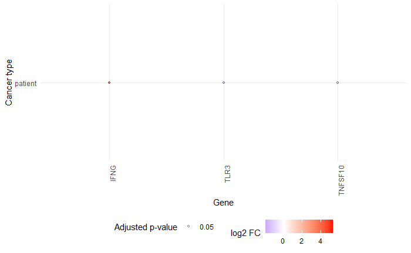

```r
plot_dgea(deseq.bbl.data.combined)
```

#### 2. Ferroptosis

Fetch the gene set of interest.

```r
genes <- read.csv(paste0(RCDdb, "Ferroptosis.csv"))
genes$gene_id <- cleanid(genes$gene_id)
genes <- distinct(genes, gene_id, .keep_all = TRUE)
genes <- subset(genes, gene_id != "")
genes
```

|  | deathtype | gene | description | gene_id | gene_biotype | pmid | comment |
| --- | --- | --- | --- | --- | --- | --- | --- |
| 1 | Ferroptosis | RPL8 | ribosomal protein L8 | ENSG00000161016 | protein_coding | 22632970 | Required in erastin-induced ferroptosis. Silencing of it conferred against erastin-induced ferroptosis. |
| 2 | Ferroptosis | IREB2 | iron responsive element binding protein 2 | ENSG00000136381 | protein_coding | 22632970 | Required in erastin-induced ferroptosis. Silencing of it conferred against erastin-induced ferroptosis. |
| 3 | Ferroptosis | ATP5MC3 | ATP synthase membrane subunit c locus 3 | ENSG00000154518 | protein_coding | 22632970 | Required in erastin-induced ferroptosis. Silencing of it conferred against erastin-induced ferroptosis. |
| 4 | Ferroptosis | CS | citrate synthase | ENSG00000062485 | protein_coding | 22632970 | Required in erastin-induced ferroptosis. Silencing of it conferred against erastin-induced ferroptosis. |
| 5 | Ferroptosis | EMC2 | ER membrane protein complex subunit 2 | ENSG00000104412 | protein_coding | 22632970 | Required in erastin-induced ferroptosis. Silencing of it conferred against erastin-induced ferroptosis. |
| 6 | Ferroptosis | ACSF2 | acyl-CoA synthetase family member 2 | ENSG00000167107 | protein_coding | 22632970 | Required in erastin-induced ferroptosis. Silencing of it conferred against erastin-induced ferroptosis. |
| 7 | Ferroptosis | NOX1 | NADPH oxidase 1 | ENSG00000007952 | protein_coding | 22632970 | Suppresses erastin-induced ferroptosis when inhibited by inhibitor. |
| 8 | Ferroptosis | CYBB | cytochrome b-245 beta chain | ENSG00000165168 | protein_coding | 22632970 | Suppresses erastin-induced ferroptosis when inhibited by inhibitor. |
| 9 | Ferroptosis | NOX3 | NADPH oxidase 3 | ENSG00000074771 | protein_coding | 22632970 | Suppresses erastin-induced ferroptosis when inhibited by inhibitor. |
| 10 | Ferroptosis | NOX4 | NADPH oxidase 4 | ENSG00000086991 | protein_coding | 22632970 | Suppresses erastin-induced ferroptosis when inhibited by inhibitor. |

[output cut: 539 more lines]

```r
deseq.bbl.data.combined <- filter_gene_set_and_perform_dgea(genes)
```

```
[1] "patient"
[1] "============="
```

```r
deseq.bbl.data.combined
```

|  | baseMean | log2FoldChange | lfcSE | stat | pvalue | padj | cancer_type | gene_symbol |
| --- | --- | --- | --- | --- | --- | --- | --- | --- |
| ENSG00000004799 | 1595.366078 | -1.998275 | 0.7201046 | -2.774979 | 5.520528e-03 | 2.967284e-02 | patient | PDK4 |
| ENSG00000012660 | 810.826535 | 1.534142 | 0.5118939 | 2.996992 | 2.726575e-03 | 1.697084e-02 | patient | ELOVL5 |
| ENSG00000015413 | 1515.830522 | 7.760628 | 0.6274588 | 12.368348 | 3.877150e-35 | 1.667175e-32 | patient | DPEP1 |
| ENSG00000047457 | 191.341620 | -3.520339 | 0.8359202 | -4.211334 | 2.538676e-05 | 4.548461e-04 | patient | CP |
| ENSG00000049759 | 2372.903421 | -1.942192 | 0.4697153 | -4.134828 | 3.552203e-05 | 5.874798e-04 | patient | NEDD4L |
| ENSG00000060762 | 489.285122 | -1.543547 | 0.4877965 | -3.164326 | 1.554425e-03 | 1.068723e-02 | patient | MPC1 |
| ENSG00000090889 | 229.448185 | 1.856812 | 0.4076148 | 4.555311 | 5.230809e-06 | 1.249582e-04 | patient | KIF4A |
| ENSG00000091513 | 27.184091 | -2.361959 | 0.7507994 | -3.145926 | 1.655622e-03 | 1.110342e-02 | patient | TF |
| ENSG00000099194 | 5121.636154 | 2.212802 | 0.5082878 | 4.353444 | 1.340153e-05 | 2.744123e-04 | patient | SCD |
| ENSG00000101444 | 3138.716595 | 2.338928 | 0.3939768 | 5.936715 | 2.907899e-09 | 2.083994e-07 | patient | AHCY |

[output cut: 34 more lines]

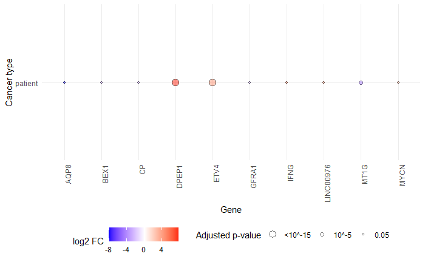

```r
plot_dgea(deseq.bbl.data.combined)
```

#### 3. Pyroptosis

Fetch the gene set of interest.

```r
genes <- read.csv(paste0(RCDdb, "Pyroptosis.csv"))
genes$gene_id <- cleanid(genes$gene_id)
genes <- distinct(genes, gene_id, .keep_all = TRUE)
genes <- subset(genes, gene_id != "")
genes
```

|  | deathtype | gene | description | gene_id | gene_biotype | pmid | comment |
| --- | --- | --- | --- | --- | --- | --- | --- |
| 1 | Pyroptosis | BAK1 | BCL2 antagonist/killer 1 | ENSG00000030110 | protein_coding | 35439536 | BAK1 is a protein that promotes cell apoptosis. The protein level of BAK1 in cells treated with BPA is significantly higher than that in the control group. The action of YVAD clearly shows that caspas… |
| 2 | Pyroptosis | BAX | BCL2 associated X, apoptosis regulator | ENSG00000087088 | protein_coding | 32332857 | Chemotherapy-induced pyroptosis in cancer cells is mediated by BAK/BAX-caspase-3-GSDME signaling pathway. |
| 3 | Pyroptosis | CASP1 | caspase 1 | ENSG00000137752 | protein_coding | 34531375 | PRMT5 can regulate cell pyroptosis in multiple myeloma by inhibiting the expression of CASP1. When PRMT5 expression is interfered, the expression of CASP1 is upregulated, thus promoting pyroptosis of … |
| 4 | Pyroptosis | CASP3 | caspase 3 | ENSG00000164305 | protein_coding | 33133646 | When GSDME is highly expressed, chemotherapeutic drugs can induce CASP3-dependent Pyroptosis, thereby shrinking tumors.CASP3 is a key protein that induces apoptosis and inflammatory cell death, which … |
| 5 | Pyroptosis | CASP4 | caspase 4 | ENSG00000196954 | protein_coding | 32109412 | Site-specific autoprocessing of Caspase-4/11 generates a p10 product that binds with high affinity to the GSDMD-C domain, facilitating cleavage of GSDMD and inducing Pyroptosis. Crystal structures of … |
| 6 | Pyroptosis | CASP5 | caspase 5 | ENSG00000137757 | protein_coding | 32109412 | CASP5 can generate a p10 product that binds with high affinity to the GSDMD-C (inhibitory domain of gasdermin D), facilitating cleavage of GSDMD and inducing Pyroptosis through site-specific autoproce… |
| 7 | Pyroptosis | CASP6 | caspase 6 | ENSG00000138794 | protein_coding | 32298652 | CASP6 promotes pyroptosis induced by IAV infection and CASP6 deficiency reduces the number of cell deaths during IAV infection . In addition, CASP6 also participates in the activation of other cell de… |
| 8 | Pyroptosis | CASP8 | caspase 8 | ENSG00000064012 | protein_coding | 31748744 | The expression of enzymatically inactive CASP8(C362S) triggered the formation of ASC specks, activation of caspase-1 and secretion of IL-1\xa6\xc2, resulting in pyroptosis. |
| 9 | Pyroptosis | CASP9 | caspase 9 | ENSG00000132906 | protein_coding | 27174943 | CASP9 does not seem to be directly related to Necroptosis.Injection of a CAS-9 inhibitor significantly inhibits high level CASP-1 activity in PI+/annexin V- (one of the characteristics of pyroptosis) … |
| 10 | Pyroptosis | SCAF11 | SR-related CTD associated factor 11 | ENSG00000139218 | protein_coding | 32109412 | CASP11 is involved in Pyroptosis by cleaving the Pyroptosis execution protein GSDMD to induce dimerization-mediated caspase activation and cleavage, and allowing the pore-forming domain of GSDMD to br… |

[output cut: 41 more lines]

```r
deseq.bbl.data.combined <- filter_gene_set_and_perform_dgea(genes)
```

```
[1] "patient"
[1] "============="
```

```r
deseq.bbl.data.combined
```

|  | baseMean | log2FoldChange | lfcSE | stat | pvalue | padj | cancer_type | gene_symbol |
| --- | --- | --- | --- | --- | --- | --- | --- | --- |
| ENSG00000022556 | 40.21183 | -3.425445 | 1.1302064 | -3.030814 | 2.438958e-03 | 2.180713e-02 | patient | NLRP2 |
| ENSG00000100453 | 69.88649 | 2.807922 | 0.5266657 | 5.331506 | 9.740150e-08 | 4.870075e-06 | patient | GZMB |
| ENSG00000174885 | 32.82102 | 3.805594 | 1.2645306 | 3.009491 | 2.616855e-03 | 2.180713e-02 | patient | NLRP6 |

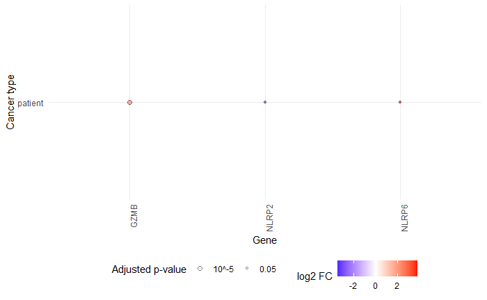

```r
plot_dgea(deseq.bbl.data.combined)
```

[^1]: De La Salle University, Manila, Philippines, gonzales.markedward@gmail.com
[^2]: De La Salle University, Manila, Philippines, anish.shrestha@dlsu.edu.ph